# modelAndEDA FINAL pdf

- Introduction & Dataset analysis
  - Feature Overview
  - Statistical Summary
  - Data Types
  - Dataset Insights and Feature Types
- Data Treatment
  - Missing Values
  - Alert missing values imputation strategy
    - Location missing values imputation strategy
    - Country missing values imputation strategy
    - Continent missing values imputation strategy
  - Missing data findings and resaolutions
  - Encoding Categorical Features and Text Features
  - Further data visualization and issue identification
  - Scaling our features
    - Data Splitting
  - Feature Reduction, analysis and selection
    - Feature engineering
    - Feature Importance Ranking (SHAP and GINI combined) along with Domain Relevance
  - An imbalnced dataset
    - Dataset imbalance handling techniques discussion
- Data limitation and quality issues
- Ethics and Privacy Considerations
- Model Selection Rationale
  - Model 1: Logistic Regression with Class Weights
  - Model 2: Gradient Boosting classifier
- Research questions
- Model Training
  - Model 1: Logistic Regression
    - Hyperparameter Tuning for Logistic Regression
    - Exploring C (regularization strength)
    - Further Hyperparameter Tuning for general performance improvement (max iterations and tolerance)
    - Class weight tuning
    - Hyperparameter Optimization and Visualization
    - Grid Search for Hyperparameter Optimization
  - Model 2: Gradient Boosting Classifier
    - Hyperparameter Tuning for Gradient Boosting Classifier
    - Tree depth and number of estimators tuning
    - Hyperparameter Optimization and Visualization
    - Grid Search for Hyperparameter Optimization
- Results and Evaluation
  - Training, Validation, and Test Performance comparison
  - Precision, Recall, and F1-Score comparison
  - ROC and AUC performance comparison
  - Confusion Matrix Analysis
  - Statistical Significance Testing
  - Model comparison summary
  - Research questions
- Novelty
- Reflection
- References
- Appendix
  - AI Usage Disclosure

https://www.kaggle.com/datasets/warcoder/earthquake-dataset?select=earthquake_1995-2023.csv

```python
import pandas as pd
import numpy as np
import matplotlib.pyplot as plt
import missingno as msno
import seaborn as sns
```

## Introduction and Dataset Overview

This dataset was compiled by Chirag Chauhan and uploaded to Kaggle. It contains data on 782 significant earthquakes worldwide from 2001 to 2022. The dataset contains various features related to earthquakes. The data origninates from the United States Geological Survey (USGS) earthquake everywhere API (Chauhan, 2024). There are various real world applications for this dataset, including earthquake analysis, tsunami risk prediction, and seismic hazard assessment.

My objective is to build a model that utilises this dataset to predict the occurrence of tsunamis following earthquakes based on the characteristics of the seismic events, something this dataset is well suited for given its selection of features. This has been something of interest for the seismology community, the topic area the dataset belongs to for sometime, with various studies having been conducted on the relationship between earthquake characteristics and tsunami generation (Lomax, Michelini and Piatanesi, 2011). If successful, this model could potentially be used to enhance tsunami warning systems, providing timely alerts to vulnerable coastal regions and reducing the impact of tsunamis on human lives and infrastructure.

### Feature Overview

| Column | Description |
| --- | --- |
| title | Name given to earthquake |
| magnitude | Magnitude of earthquake |
| date_time | Date and time |
| cdi | Maximum reported intensity for event range |
| mmi | Maximum estimated instrumental intensity for event |
| alert | Alert level, “green”, “yellow”, “orange”, and “red” |
| tsunami | "1" for events in oceanic regions and "0" otherwise |
| sig | Number describing how significant the event is. Larger numbers indicate a more significant event. This value is determined by magnitude, maximum MMI, felt reports, and estimated impact |
| net | ID of a data contributor. Identifies the network considered to be the preferred source of information for this event. |
| nst | Total number of seismic stations used to determine earthquake location. |
| dmin | Horizontal distance from the epicenter to the nearest station |
| gap | Largest azimuthal gap between azimuthally adjacent stations (in degrees). Smaller numbers indicate more reliable positions. Gaps >180° have large uncertainties |
| magType | Method or algorithm used to calculate the preferred magnitude for the event |
| depth | Depth where the earthquake begins to rupture |
| latitude | Latitude coordinate of the earthquake |
| longitude | Longitude coordinate of the earthquake |
| location | Location within the country |
| continent | Continent of the earthquake-hit country |
| country | Affected country |

(figure 1)

(Chauhan, 2024)

```python
df = pd.read_csv('data/earthquake_data.csv')
```

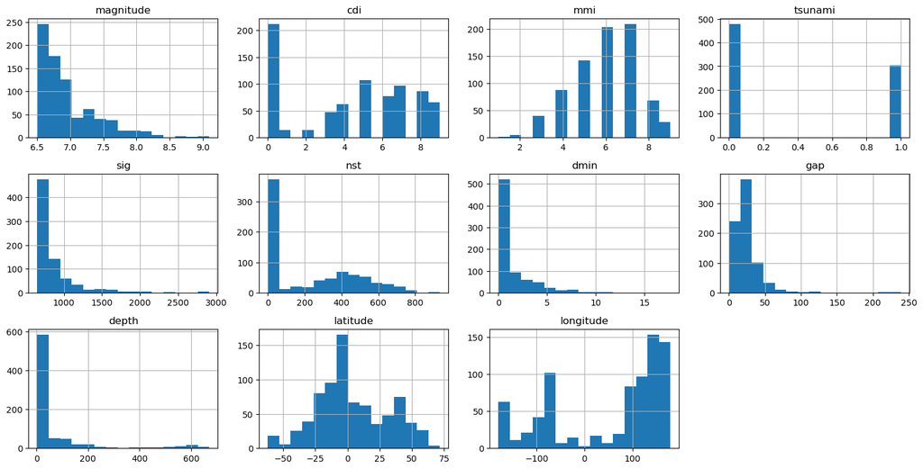

```python
df.hist(bins=15, figsize=(15,10), layout=(4,4))
plt.tight_layout()
plt.show()
```

Figure 2: Histograms of Numerical Features

```python
df.sample(16)
```

|  | title | magnitude | date_time | cdi | mmi | alert | tsunami | sig | net | nst | dmin | gap | magType | depth | latitude | longitude | location | continent | country |
| --- | --- | --- | --- | --- | --- | --- | --- | --- | --- | --- | --- | --- | --- | --- | --- | --- | --- | --- | --- |
| 233 | M 6.5 - 92 km SSW of Blenheim, New Zealand | 6.5 | 13-11-2016 11:32 | 6 | 7 | yellow | 1 | 656 | us | 0 | 0.135 | 58.0 | mww | 10.00 | -42.3205 | 173.6690 | Blenheim, New Zealand | NaN | New Zealand |
| 597 | M 8.0 - 41 km SW of San Vicente de Cañete, Peru | 8.0 | 15-08-2007 23:40 | 9 | 8 | NaN | 0 | 1385 | us | 625 | 0.000 | 25.7 | mwc | 39.00 | -13.3860 | -76.6030 | San Vicente de Cañete, Peru | NaN | Peru |
| 188 | M 6.6 - 74 km E of Tadine, New Caledonia | 6.6 | 19-11-2017 15:09 | 4 | 5 | green | 1 | 676 | us | 0 | 0.529 | 21.0 | mww | 13.00 | -21.5027 | 168.5980 | Tadine, New Caledonia | NaN | NaN |
| 394 | M 7.4 - 292 km SW of Vaini, Tonga | 7.4 | 23-05-2013 17:19 | 0 | 6 | green | 1 | 842 | us | 626 | 0.000 | 16.0 | mww | 173.70 | -23.0090 | -177.2320 | Vaini, Tonga | NaN | NaN |
| 84 | M 7.6 - 99 km SE of Sand Point, Alaska | 7.6 | 19-10-2020 20:54 | 9 | 7 | yellow | 1 | 1165 | us | 0 | 0.230 | 36.0 | mww | 28.37 | 54.6620 | -159.6750 | Sand Point, Alaska | North America | United States of America |
| 719 | M 6.6 - 87 km SSE of Kokopo, Papua New Guinea | 6.6 | 07-06-2003 00:32 | 0 | 6 | NaN | 0 | 670 | us | 419 | 0.000 | 27.8 | mwc | 33.00 | -5.0950 | 152.5020 | Kokopo, Papua New Guinea | NaN | Papua New Guinea |
| 267 | M 6.7 - 125 km SSW of Tarauacá, Brazil | 6.7 | 26-11-2015 05:45 | 2 | 3 | green | 0 | 691 | us | 0 | 2.033 | 19.0 | mww | 602.75 | -9.1825 | -71.2574 | Tarauacá, Brazil | South America | Brazil |
| 316 | M 6.5 - 236 km S of Punta de Burica, Panama | 6.5 | 07-01-2015 05:07 | 1 | 4 | green | 1 | 650 | us | 0 | 4.318 | 61.0 | mww | 8.00 | 5.9045 | -82.6576 | Punta de Burica, Panama | NaN | NaN |
| 641 | M 6.5 - 57 km SE of Sinabang, Indonesia | 6.5 | 19-11-2005 14:10 | 3 | 6 | NaN | 0 | 651 | us | 358 | 0.000 | 20.7 | mwb | 21.00 | 2.1640 | 96.7860 | Sinabang, Indonesia | NaN | Indonesia |
| 53 | M 7.2 - Nippes, Haiti | 7.2 | 14-08-2021 12:29 | 9 | 8 | red | 1 | 2331 | us | 0 | 1.178 | 23.0 | mww | 10.00 | 18.3521 | -73.4804 | Nippes, Haiti | North America | Haiti |
| 220 | M 6.9 - 225 km SW of Nadi, Fiji | 6.9 | 03-01-2017 21:52 | 6 | 4 | green | 1 | 742 | us | 0 | 2.495 | 13.0 | mww | 12.00 | -19.3733 | 176.0520 | Nadi, Fiji | NaN | NaN |
| 428 | M 7.6 - 11 km ENE of Hojancha, Costa Rica | 7.6 | 05-09-2012 14:42 | 8 | 7 | NaN | 0 | 1555 | us | 703 | 0.000 | 34.3 | mww | 35.00 | 10.0850 | -85.3150 | Hojancha, Costa Rica | NaN | Costa Rica |
| 261 | M 6.7 - 52 km SE of Shizunai-furukawach?, Japan | 6.7 | 14-01-2016 03:25 | 5 | 6 | green | 1 | 717 | us | 0 | 0.281 | 22.0 | mww | 46.00 | 41.9723 | 142.7810 | Shizunai-furukawach?, Japan | Asia | Japan |
| 395 | M 6.8 - Pagan region, Northern Mariana Islands | 6.8 | 14-05-2013 00:32 | 0 | 3 | green | 0 | 711 | us | 131 | 0.000 | 18.0 | mww | 602.20 | 18.7280 | 145.2880 | Pagan region, Northern Mariana Islands | NaN | NaN |
| 79 | M 6.9 - South Shetland Islands | 6.9 | 23-01-2021 23:36 | 9 | 5 | green | 1 | 739 | us | 0 | 1.550 | 16.0 | mww | 15.00 | -61.8484 | -55.5590 | South Shetland Islands | NaN | Antarctica |
| 419 | M 7.1 - Banda Sea | 7.1 | 10-12-2012 16:53 | 5 | 5 | NaN | 0 | 843 | us | 517 | 0.000 | 8.7 | mww | 155.00 | -6.5330 | 129.8250 | Banda Sea | NaN | Indonesia |

### Statistical Summary

```python
df.describe()
```

|  | magnitude | cdi | mmi | tsunami | sig | nst | dmin | gap | depth | latitude | longitude |
| --- | --- | --- | --- | --- | --- | --- | --- | --- | --- | --- | --- |
| count | 782.000000 | 782.000000 | 782.000000 | 782.000000 | 782.000000 | 782.000000 | 782.000000 | 782.000000 | 782.000000 | 782.000000 | 782.000000 |
| mean | 6.941125 | 4.333760 | 5.964194 | 0.388747 | 870.108696 | 230.250639 | 1.325757 | 25.038990 | 75.883199 | 3.538100 | 52.609199 |
| std | 0.445514 | 3.169939 | 1.462724 | 0.487778 | 322.465367 | 250.188177 | 2.218805 | 24.225067 | 137.277078 | 27.303429 | 117.898886 |
| min | 6.500000 | 0.000000 | 1.000000 | 0.000000 | 650.000000 | 0.000000 | 0.000000 | 0.000000 | 2.700000 | -61.848400 | -179.968000 |
| 25% | 6.600000 | 0.000000 | 5.000000 | 0.000000 | 691.000000 | 0.000000 | 0.000000 | 14.625000 | 14.000000 | -14.595600 | -71.668050 |
| 50% | 6.800000 | 5.000000 | 6.000000 | 0.000000 | 754.000000 | 140.000000 | 0.000000 | 20.000000 | 26.295000 | -2.572500 | 109.426000 |
| 75% | 7.100000 | 7.000000 | 7.000000 | 1.000000 | 909.750000 | 445.000000 | 1.863000 | 30.000000 | 49.750000 | 24.654500 | 148.941000 |
| max | 9.100000 | 9.000000 | 9.000000 | 1.000000 | 2910.000000 | 934.000000 | 17.654000 | 239.000000 | 670.810000 | 71.631200 | 179.662000 |

```python
print(f'Dataset Shape: {df.shape}')
print(f"Rows: {df.shape[0]}, Columns: {df.shape[1]}")
print('Column Names:', df.columns.tolist())
```

[output not shown]

### Data Types

```python
unique_values = df.nunique()
print(f'Unique values per column:\n{unique_values}')
country_unique_variables_before_imputation = df['country'].nunique()
```

```
Unique values per column:
title        768
magnitude     24
date_time    773
cdi           10
mmi            9
alert          4
tsunami        2
sig          339
net           11
nst          312
dmin         369
gap          256
magType        9
depth        303
latitude     778
longitude    777
location     413
continent      6
country       49
dtype: int64
```

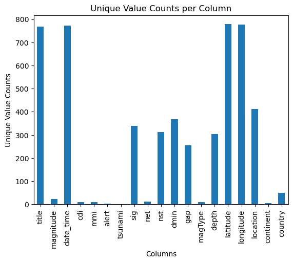

```python
df.nunique(axis=0).plot(kind='bar')
plt.title('Unique Value Counts per Column')
plt.xlabel('Columns')
plt.ylabel('Unique Value Counts')
plt.show()
```

Figure 3: This chart displays the number of unique values in each dataset column, helping distinguish categorical features (with fewer unique values) from numerical features (with many).

```python
print(df.dtypes)
```

```
title         object
magnitude    float64
date_time     object
cdi            int64
mmi            int64
alert         object
tsunami        int64
sig            int64
net           object
nst            int64
dmin         float64
gap          float64
magType       object
depth        float64
latitude     float64
longitude    float64
location      object
continent     object
country       object
dtype: object
```

### Dataset Insights and Feature Types

Figure 3 and the data-type overview show that the dataset contains both numerical and categorical features, requiring tailored preprocessing. According to the USGS, `mmi` and `cdi` are discrete intensity scales, whereas `magnitude` represents a continuous measure of energy release; therefore, `magnitude` will be treated as numerical and cdi/mmi as ordered categorical variables (United States Geological Survey, no date; Wald et al., 2011; United States Geological Survey, 1989). `title` and `location` are unstructured text features due to their object types and high uniqueness, while `date_time` is a datetime variable.

The target variable, `tsunami`, is a binary numerical feature with two values (0 and 1), indicating whether a tsunami followed the earthquake. As noted in Chauhan (2024), this makes it well aligned with the with the goal of predicting tsunami occurrence via binary classification models.

| Types of data | Features |
| --- | --- |
| Numerical Features | `magnitude`, `sig`, `nst`, `dmin`, `gap`, `depth`, `latitude`, `longitude` |
| Categorical Numerical Features | `cdi`, `mmi` |
| Datetime Feature | `date_time` |
| Categorical Text Feature | `alert`, `net`, `magType`, `continent`, `country` |
| Unstructured Text Feature | `title`, `location` |
| Target Variable (Binary Numerical) | `tsunami` |

Figure 4: Data Types of Features and Target Variable

## Data Treatment

### Missing Values

```python
print(df.isnull().sum())
```

```
title          0
magnitude      0
date_time      0
cdi            0
mmi            0
alert        367
tsunami        0
sig            0
net            0
nst            0
dmin           0
gap            0
magType        0
depth          0
latitude       0
longitude      0
location       5
continent    576
country      298
dtype: int64
```

```python
place_holders = [-9999, 9999, np.inf, -np.inf, 'nan', 'NaN', 'NA', 'null', 'NULL', '']
print(df.isin(place_holders).sum().sum() + df.isnull().sum().sum())
```

```
1246
```

```python
missing_percentage = (df.isnull().sum() / len(df)) * 100
missing_percentage = missing_percentage[missing_percentage > 0]
print(f'Percentage of missing values per column:\n{missing_percentage}')
```

```
Percentage of missing values per column:
alert        46.930946
location      0.639386
continent    73.657289
country      38.107417
dtype: float64
```

```python
missing_values_datatypes = df[missing_percentage.index].dtypes
print(f'Data types of columns with missing values:\n{missing_values_datatypes}')
```

```
Data types of columns with missing values:
alert        object
location     object
continent    object
country      object
dtype: object
```

```python
df[missing_percentage.index].sample(16)
```

|  | alert | location | continent | country |
| --- | --- | --- | --- | --- |
| 334 | green | Mata-Utu, Wallis and Futuna | NaN | NaN |
| 433 | NaN | Kokopo, Papua New Guinea | NaN | Papua New Guinea |
| 134 | green | Azángaro, Peru | South America | Peru |
| 115 | green | Constitución, Chile | NaN | NaN |
| 302 | green | Panguna, Papua New Guinea | NaN | NaN |
| 606 | NaN | Gizo, Solomon Islands | NaN | Solomon Islands |
| 398 | green | Kuril’sk, Russia | Asia | Russia |
| 154 | green | Tadine, New Caledonia | NaN | NaN |
| 688 | NaN | Manokwari, Indonesia | NaN | Indonesia |
| 377 | green | Atiquipa, Peru | NaN | Peru |
| 338 | green | Kermadec Islands, New Zealand | NaN | NaN |
| 310 | green | Hihifo, Tonga | NaN | NaN |
| 289 | green | Abepura, Indonesia | NaN | Indonesia |
| 352 | green | Panguna, Papua New Guinea | NaN | Papua New Guinea |
| 74 | green | Kermadec Islands, New Zealand | NaN | NaN |
| 321 | green | Tobelo, Indonesia | NaN | Indonesia |

| **Feature** | **Type of Missingness** | **Reason / Explanation** |
| --- | --- | --- |
| **Alert Level** | Missing Not At Random (MNAR) | Missingness is related to the unobserved value itself, less significant earthquakes are less likely to have an alert level assigned. |
| **Location** | Missing At Random (MAR) | Missingness depends on other observed variables (latitude and longitude). Location may not be recorded because coordinates are already available. |
| **Country** | Missing At Random (MAR) | Missingness is related to latitude and longitude data, the country may be inferred from coordinates, making direct recording unnecessary. |
| **Continent** | Missing At Random (MAR) | Missingness depends on other observed information (such as latitude, longitude, or country) and is not directly related to the continent value itself. |

Figure 10: Missingness Types for Features with Missing Data

### Alert missing values imputation strategy

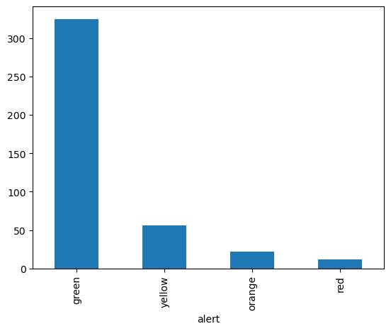

```python
df['alert'].value_counts().plot(kind='bar')
```

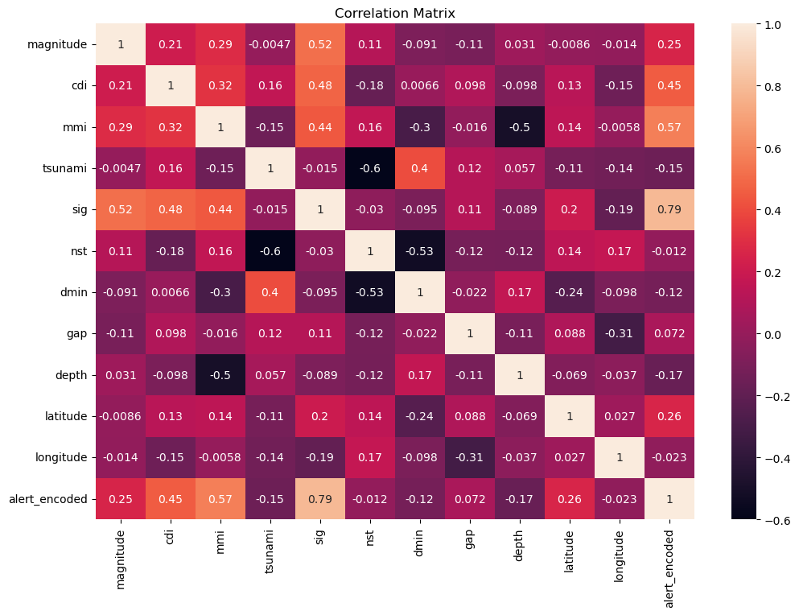

```python
alert_order = {'green': 1, 'yellow': 2, 'orange': 3, 'red': 4}
df_temp = df.copy()
df_temp['alert_encoded'] = df_temp['alert'].map(alert_order)
numerical_cols = df_temp.select_dtypes(include=[np.number]).columns.tolist()
corr_matrix = df_temp[numerical_cols].corr()
plt.figure(figsize=(12,8))
sns.heatmap(corr_matrix, annot=True)
plt.title('Correlation Matrix')
plt.show()
```

Figure 6: Correlation between Numerical Features and Encoded Alert Levels

```python
print(df.groupby('alert').agg({
    'sig': ['mean']
}).sig)
```

```
               mean
alert
green    773.224615
orange  1382.136364
red     2475.000000
yellow  1047.696429
```

```python
alert_thresholds = df.groupby('alert').agg({
    'sig': ['mean']
}).sig

green_threshold = alert_thresholds.loc['green', 'mean'] #index by alert level, get column 'mean'
yellow_threshold = alert_thresholds.loc['yellow', 'mean']
orange_threshold = alert_thresholds.loc['orange', 'mean']
red_threshold = alert_thresholds.loc['red', 'mean']

#Order of alert levels: red, orange, yellow, green - source: (United States Geological Survey, 2010)

def impute_alert(row):
    if pd.isnull(row['alert']):
        if row['sig'] >= red_threshold:
            return 'red'
        elif row['sig'] >= orange_threshold:
            return 'orange'
        elif row['sig'] >= yellow_threshold:
            return 'yellow'
        else:
            return 'green'
    else:
        return row['alert']
df['alert'] = df.apply(impute_alert, axis=1)
print(f'Missing values in alert column after imputation: {df["alert"].isnull().sum()}')
```

```
Missing values in alert column after imputation: 0
```

#### Location missing values imputation strategy

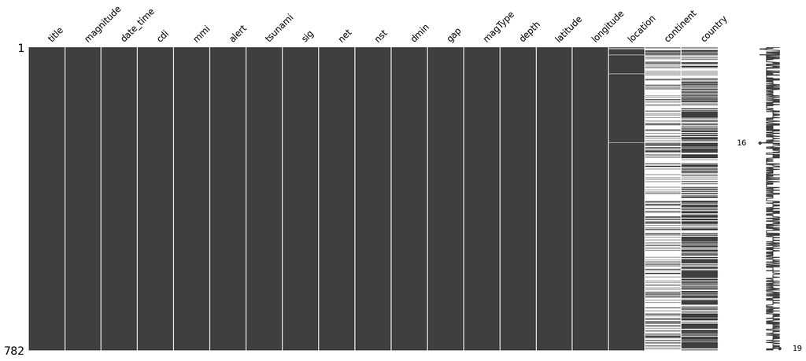

```python
msno.matrix(df)
```

Figure 7: Missingness Pattern for All Features

```python
print(f'Missing values in location column before imputation: {df["location"].isnull().sum()}')
def impute_location(row):
    if pd.isnull(row['location']):
        if not pd.isnull(row['country']):
            return f'{row["country"]}'
        else:
            return np.nan # cannot impute location
    else:
        return row['location']
df['location'] = df.apply(impute_location, axis=1)
print(f'Missing values in location column after imputation: {df["location"].isnull().sum()}')
```

```
Missing values in location column before imputation: 5
Missing values in location column after imputation: 3
```

```python
df = df.dropna(subset=['location'])
print('Data shape after dropping rows with missing location:', df.shape)
```

```
Data shape after dropping rows with missing location: (779, 19)
```

```python
print(df.location.sample(15))
```

```
53                     Nippes, Haiti
353                   Iquique, Chile
559                     Namie, Japan
191        Angoram, Papua New Guinea
225        Kirakira, Solomon Islands
610               Ternate, Indonesia
624          Kimbe, Papua New Guinea
343                   Vernon, Canada
27     Kermadec Islands, New Zealand
644         Kokopo, Papua New Guinea
15              the Kermadec Islands
253           Ashk?sham, Afghanistan
90               Bengkulu, Indonesia
601                    Mikuni, Japan
377                   Atiquipa, Peru
Name: location, dtype: object
```

#### Country missing values imputation strategy

```python
coma_count = df['location'].str.contains(',').sum()
print(f'Percentage of locations with a comma: {(coma_count / len(df)) * 100:.2f}%')
```

```
Percentage of locations with a comma: 91.40%
```

Figure 18: Many location entries include an area–country format (e.g., "Los Angeles, USA"), enabling missing country values to be inferred.

```python
print(f'Missing values in country column before imputation: {df["country"].isnull().sum()}')
def impute_country(row):
    if pd.isnull(row['country']):
        if ',' in row['location']:
            return row['location'].split(',')[-1].strip() # extract country from location using the last part after comma
        else:
            return np.nan # cannot impute country
    else:
        return row['country']

df['country'] = df.apply(impute_country, axis=1)
print(f'Missing values in country column after imputation: {df["country"].isnull().sum()}')
```

```
Missing values in country column before imputation: 295
Missing values in country column after imputation: 42
```

```python
missing_country_locations = df[df['country'].isnull()]['location']
print(f'Locations with missing country values:\n{missing_country_locations}')
```

```
Locations with missing country values:
5                            the Fiji Islands
6                            the Fiji Islands
15                       the Kermadec Islands
22                        the Loyalty Islands
28                           the Fiji Islands
30                    Kermadec Islands region
45                             Vanuatu region
46                             Vanuatu region
52              South Sandwich Islands region
56              South Sandwich Islands region
57              South Sandwich Islands region
67                 Mauritius - Reunion region
73                    Kermadec Islands region
78                        the Loyalty Islands
```

[output cut: 29 more lines]

Many of the 42 samples lacking country data correspond to small islands, territories, ocean regions, or disputed areas.

```python
df['country'] = df['country'].fillna(df['location'])
print(f'Missing values in country column after final imputation: {df["country"].isnull().sum()}')
```

```
Missing values in country column after final imputation: 0
```

#### Continent missing values imputation strategy

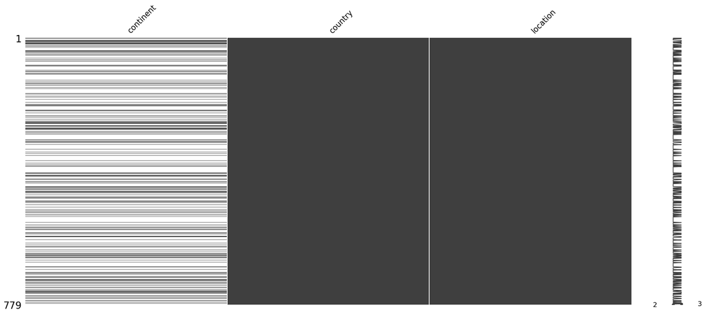

```python
msno.matrix(df[['continent', 'country', 'location']])
```

```python
df = df.drop(columns=['continent'])
print(df.columns)
```

```
Index(['title', 'magnitude', 'date_time', 'cdi', 'mmi', 'alert', 'tsunami',
       'sig', 'net', 'nst', 'dmin', 'gap', 'magType', 'depth', 'latitude',
       'longitude', 'location', 'country'],
      dtype='object')
```

```python
total_missing_after = df.isnull().sum().sum()
print(f'Total missing values after imputation: {total_missing_after}')
```

```
Total missing values after imputation: 0
```

```python
X, y = df.drop(columns='tsunami'), df['tsunami']
X.shape, y.shape, X.columns
```

```
((779, 17),
 (779,),
 Index(['title', 'magnitude', 'date_time', 'cdi', 'mmi', 'alert', 'sig', 'net',
        'nst', 'dmin', 'gap', 'magType', 'depth', 'latitude', 'longitude',
        'location', 'country'],
       dtype='object'))
```

### Missing data findings and resolutions

I initially examined missing data patterns using both percentage based calculations and visualizations (Figure 7), identifying the extent and type of missingness across features (Figure 10). Imputation strategies were tailored accordingly: rule based imputation was applied to `alert` based on its correlation with `sig` (figure 6), while inter feature relationships guided imputation for `location` and `country`. The `continent` feature was dropped due to excessive missingness. These approaches aimed to preserve data integrity and minimize imputation bias.

### Encoding Categorical Features and Text Features

```python
from sklearn.preprocessing import OrdinalEncoder
ordinal_features = ['alert']
ordinal_encoder = OrdinalEncoder(categories=[['green', 'yellow', 'orange', 'red']])
X[ordinal_features] = ordinal_encoder.fit_transform(X[ordinal_features])
```

I must also encode the remaining categorical text features (`net`, `magType`, `country`, Figure 3). As these are nominal with no inherent order (Figure 1), I will apply one-hot encoding to convert each category into binary indicator variables.

```python
#one-hot encoding of nominal categorical features
columns_before = X.shape[1]
nominal_features = ['net', 'magType']
X = pd.get_dummies(X, columns=nominal_features, drop_first=True)
columns_after = X.shape[1]
```

[output not shown]

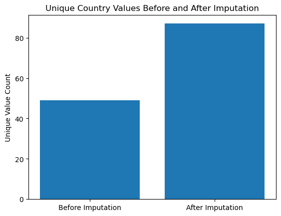

```python
print(country_unique_variables_before_imputation)
print(df.country.nunique())
plt.bar(['Before Imputation', 'After Imputation'], [country_unique_variables_before_imputation, df.country.nunique()])
plt.title('Unique Country Values Before and After Imputation')
plt.ylabel('Unique Value Count')
plt.show()
```

```python
X[['country', 'location']].sample(16)
```

|  | country | location |
| --- | --- | --- |
| 23 | New Caledonia | Tadine, New Caledonia |
| 130 | Papua New Guinea | Namatanai, Papua New Guinea |
| 525 | Fiji | Ba, Fiji |
| 443 | Papua New Guinea | Kainantu, Papua New Guinea |
| 326 | El Salvador | Intipucá, El Salvador |
| 681 | Nicaragua | Masachapa, Nicaragua |
| 378 | Pakistan | Bela, Pakistan |
| 414 | Solomon Islands | Lata, Solomon Islands |
| 59 | Alaska | Perryville, Alaska |
| 174 | United States of America | Leilani Estates, Hawaii |
| 613 | Taiwan | Hengchun, Taiwan |
| 563 | Japan | Hasaki, Japan |
| 76 | New Zealand | Gisborne, New Zealand |
| 272 | Japan | Makurazaki, Japan |
| 648 | India region | Nicobar Islands, India region |
| 471 | Myanmar | Tachilek, Myanmar |

figure 9: Location and Country content sample

```python
X = X.drop(columns=['country'])
```

I now need to process the unstructured text features (`title` and `location`, Figure 4). As free-form text, they must be vectorised into numerical features before modelling. Since `Country` largely overlaps with `location` (Figures 9, 18), I keep only `location` to avoid redundancy and unnecessary dimensionality.

```python
import gensim.downloader as api
word2vec_model = api.load('glove-wiki-gigaword-50') #pre-trained Word2Vec model with 50-dimensional vectors

def average_word_vectors(text, model): #Averaging vectors Inspired by (itdxer, 2017), novel approach for small datasets (keep dimensionality to 50)
    words = str(text).lower().split()
    vectors = []
    for word in words:
        if word in model: #When you iterate through model, you get the words in the vocabulary (it must have a custom __iter__ method)
            vectors.append(model[word])
    if vectors:
        return np.mean(vectors, axis=0)
    else:
        return np.zeros(model.vector_size)

title_vectors = X['title'].apply(lambda x: average_word_vectors(x, word2vec_model))
location_vectors = X['location'].apply(lambda x: average_word_vectors(x, word2vec_model))
title_df = pd.DataFrame(title_vectors.tolist(), index=X.index).add_prefix('title_vec_') #takes index from original X to align rows
location_df = pd.DataFrame(location_vectors.tolist(), index=X.index).add_prefix('location_vec_')
X = pd.concat([X, title_df, location_df], axis=1)
X = X.drop(columns=['title', 'location'])
X
```

|  | magnitude | date_time | cdi | mmi | alert | sig | nst | dmin | gap | depth | ... | location_vec_40 | location_vec_41 | location_vec_42 | location_vec_43 | location_vec_44 | location_vec_45 | location_vec_46 | location_vec_47 | location_vec_48 | location_vec_49 |
| --- | --- | --- | --- | --- | --- | --- | --- | --- | --- | --- | --- | --- | --- | --- | --- | --- | --- | --- | --- | --- | --- |
| 0 | 7.0 | 22-11-2022 02:03 | 8 | 7 | 0.0 | 768 | 117 | 0.509 | 17.0 | 14.0 | ... | -0.413625 | 1.011540 | 0.835310 | -0.672395 | -1.054485 | 0.468645 | -0.376000 | -0.737735 | -0.421065 | -0.443805 |
| 1 | 6.9 | 18-11-2022 13:37 | 4 | 4 | 0.0 | 735 | 99 | 2.229 | 34.0 | 25.0 | ... | -1.397400 | 0.328640 | 0.903000 | -1.181100 | 0.236450 | 1.036200 | -0.586330 | 0.309870 | 0.325110 | -1.210100 |
| 2 | 7.0 | 12-11-2022 07:09 | 3 | 3 | 0.0 | 755 | 147 | 3.125 | 18.0 | 579.0 | ... | -0.678180 | 0.542310 | 0.366070 | -0.350280 | -0.664370 | 1.286700 | -0.978370 | 0.141160 | 0.803460 | -0.977450 |
| 3 | 7.3 | 11-11-2022 10:48 | 5 | 5 | 0.0 | 833 | 149 | 1.865 | 21.0 | 37.0 | ... | -0.083787 | 0.562320 | 0.343680 | -0.498550 | -0.811640 | 1.716400 | -0.491980 | 0.052259 | 0.706380 | -0.809750 |
| 5 | 7.0 | 09-11-2022 09:51 | 4 | 3 | 0.0 | 755 | 142 | 4.578 | 26.0 | 660.0 | ... | -0.508930 | 0.422533 | 0.538463 | -0.348069 | -0.877760 | 0.618010 | -0.535445 | -0.326447 | 0.172120 | -0.906737 |
| ... | ... | ... | ... | ... | ... | ... | ... | ... | ... | ... | ... | ... | ... | ... | ... | ... | ... | ... | ... | ... | ... |
| 777 | 7.7 | 13-01-2001 17:33 | 0 | 8 | 0.0 | 912 | 427 | 0.000 | 0.0 | 60.0 | ... | -0.525199 | 0.588573 | 0.626350 | -1.385473 | -0.272928 | -0.331966 | -0.926685 | -0.707303 | 0.474065 | -0.023720 |
| 778 | 6.9 | 10-01-2001 16:02 | 5 | 7 | 0.0 | 745 | 0 | 0.000 | 0.0 | 36.4 | ... | -0.602380 | 0.546825 | 0.408775 | 0.057960 | -0.438345 | 0.065940 | -0.293385 | -0.393100 | -0.215465 | -0.072315 |
| 779 | 7.1 | 09-01-2001 16:49 | 0 | 7 | 0.0 | 776 | 372 | 0.000 | 0.0 | 103.0 | ... | -0.660620 | 0.921090 | 0.486700 | -1.248600 | -1.001100 | 0.611220 | -0.338700 | 0.311190 | 0.707830 | -0.753600 |
| 780 | 6.8 | 01-01-2001 08:54 | 0 | 5 | 0.0 | 711 | 64 | 0.000 | 0.0 | 33.0 | ... | -1.447600 | 0.193520 | 0.699930 | -1.508400 | -0.045248 | 0.242790 | -0.459550 | -0.234900 | 0.175560 | -0.527280 |
| 781 | 7.5 | 01-01-2001 06:57 | 0 | 7 | 0.0 | 865 | 324 | 0.000 | 0.0 | 33.0 | ... | -1.447600 | 0.193520 | 0.699930 | -1.508400 | -0.045248 | 0.242790 | -0.459550 | -0.234900 | 0.175560 | -0.527280 |

779 rows × 130 columns

```python
object_columns = X.select_dtypes(include=['object']).columns.tolist()
print(f'Object type columns in X: {object_columns}')
```

```
Object type columns in X: ['date_time']
```

```python
X['time'] = pd.to_datetime(X['date_time'])
X['time'] = pd.to_datetime(X['time']).astype(int)/ 10**9 #unix timestamp - (AlwaysSunny, 2019)
X = X.drop(columns=['date_time'])
```

```python
object_columns = X.select_dtypes(include=['object']).columns.tolist()
print(f'Object type columns in X: {object_columns}')
datatime_columns = X.select_dtypes(include=['datetime64[ns]']).columns.tolist()
print(f'Datetime type columns in X: {datatime_columns}')
```

```
Object type columns in X: []
Datetime type columns in X: []
```

### Further data visualization and issue identification

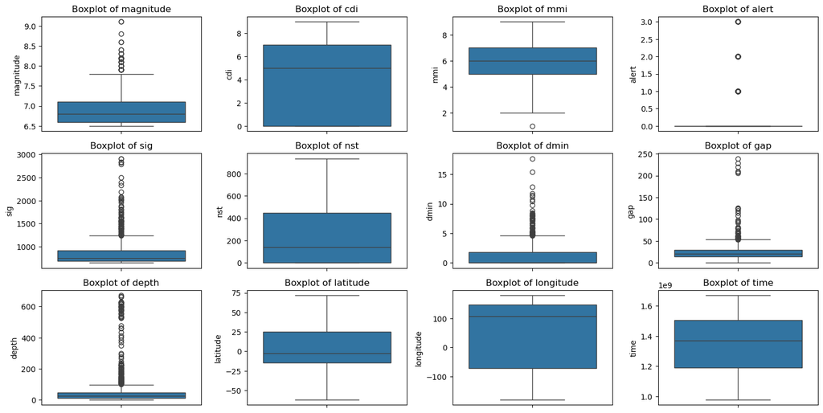

```python
non_encoded_render = [c for c in X.columns if '_' not in c] #exclude vectorized text features for boxplots because they have many dimensions
plt.figure(figsize=(15,10))
for i, col in enumerate(non_encoded_render):
    plt.subplot(4, 4, i+1)
    sns.boxplot(y=X[col])
    plt.title(f'Boxplot of {col}')
plt.tight_layout()
plt.show()
```

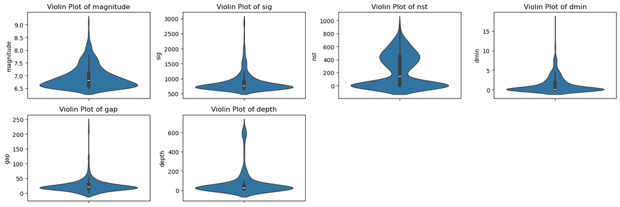

```python
features_of_interest = ['magnitude', 'sig', 'nst', 'dmin', 'gap', 'depth']
plt.figure(figsize=(15,10))
for i, col in enumerate(features_of_interest):
    plt.subplot(4, 4, i + 1)
    sns.violinplot(y=X[col])
    plt.title(f'Violin Plot of {col}')
plt.tight_layout()
plt.show()
```

```python
for col in features_of_interest:
    min_value = X[col].min()
    print(f'Minimum value in {col}: {min_value}')
```

```
Minimum value in magnitude: 6.5
Minimum value in sig: 650
Minimum value in nst: 0
Minimum value in dmin: 0.0
Minimum value in gap: 0.0
Minimum value in depth: 2.7
```

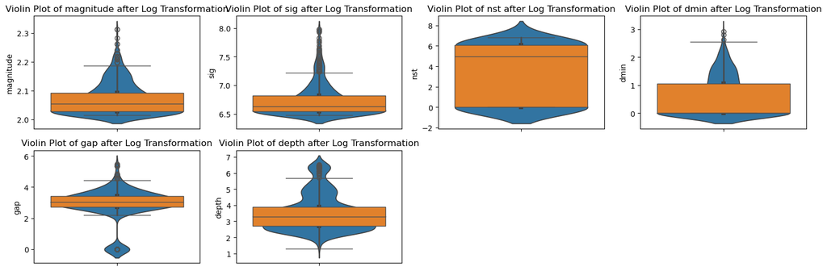

```python
X[features_of_interest] = X[features_of_interest].apply(lambda x: np.log1p(x)) #(ChatGPT, 2025)
plt.figure(figsize=(15,10))
for i, col in enumerate(features_of_interest):
    plt.subplot(4, 4, i + 1)
    sns.violinplot(y=X[col])
    sns.boxplot(y=X[col])
    plt.title(f'Violin Plot of {col} after Log Transformation')
plt.tight_layout()
plt.show()
```

```python
print(X.isnull().sum().sum())
```

```
0
```

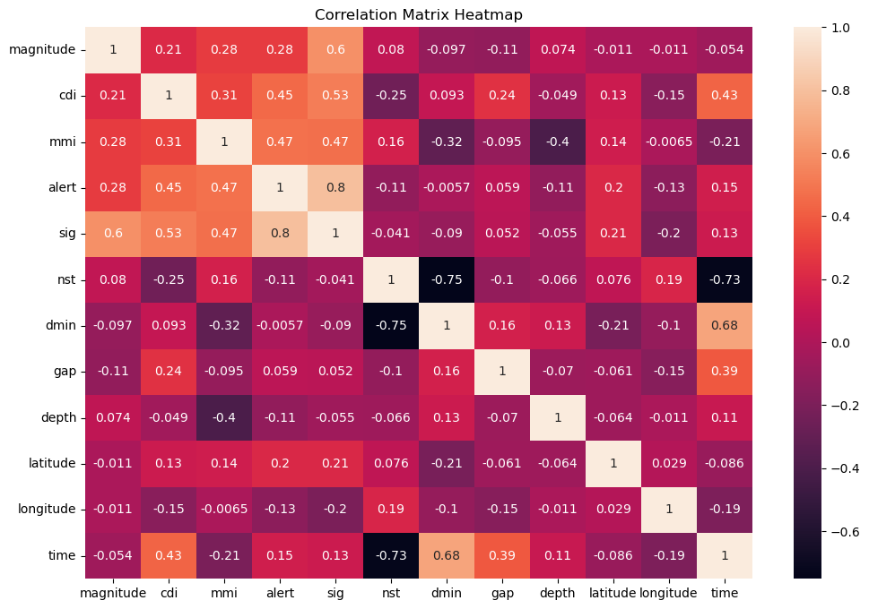

```python
corr_matrix = X[non_encoded_render].corr()
plt.figure(figsize=(12,8))
sns.heatmap(corr_matrix, annot=True)
plt.title('Correlation Matrix Heatmap')
plt.show()
```

```python
duplicate_rows = X.duplicated().sum()
print(f'Number of duplicate rows in X: {duplicate_rows}')
```

```
Number of duplicate rows in X: 0
```

### Scaling our features

The scaling of features is a critical part of data preprocessing in ML. It involves transforming the features to a common scale without distorting differences in the ranges of values. Without scaling, larger features will receive disproportionate weight updates during training if using gradient descent based algorithms, leading to unstable model training and convergence issues.

#### Data Splitting

```python
from sklearn.model_selection import train_test_split

X_train, X_test, y_train, y_test = train_test_split(X, y, test_size=0.2, stratify=y)
```

```python
from sklearn.preprocessing import StandardScaler
scaler = StandardScaler() #This is z-score normalization
scaler = scaler.fit(X_train) #fit only on training data to prevent data leakage
```

```python
X_train = scaler.transform(X_train)
X_test = scaler.transform(X_test)
X_train = pd.DataFrame(X_train, columns=X.columns, index=y_train.index)
X_test = pd.DataFrame(X_test, columns=X.columns, index=y_test.index)
```

### Feature Reduction, analysis and selection

```python
df[['country', 'location','title']].sample(16)
```

|  | country | location | title |
| --- | --- | --- | --- |
| 287 | Solomon Islands | Gizo, Solomon Islands | M 6.5 - 177 km SE of Gizo, Solomon Islands |
| 273 | Chile | Coquimbo, Chile | M 6.9 - 85 km NW of Coquimbo, Chile |
| 729 | Papua New Guinea | New Ireland region, Papua New Guinea | M 6.7 - New Ireland region, Papua New Guinea |
| 698 | New Caledonia | Tadine, New Caledonia | M 7.3 - 201 km ESE of Tadine, New Caledonia |
| 779 | Vanuatu | Port-Olry, Vanuatu | M 7.1 - 16 km NE of Port-Olry, Vanuatu |
| 99 | Chile | San Pedro de Atacama, Chile | M 6.8 - 48 km SW of San Pedro de Atacama, Chile |
| 269 | Peru | Iñapari, Peru | M 7.6 - 155 km WNW of Iñapari, Peru |
| 457 | Indonesia | Kabanjahe, Indonesia | M 6.7 - 68 km WSW of Kabanjahe, Indonesia |
| 268 | Peru | Iñapari, Peru | M 7.6 - 185 km WNW of Iñapari, Peru |
| 313 | Japan | Miyako, Japan | M 6.7 - 83 km ENE of Miyako, Japan |
| 73 | Kermadec Islands region | Kermadec Islands region | M 6.5 - Kermadec Islands region |
| 628 | Tonga | Pangai, Tonga | M 8.0 - 50 km ESE of Pangai, Tonga |
| 596 | Solomon Islands | Malango, Solomon Islands | M 6.5 - 31 km WSW of Malango, Solomon Islands |
| 549 | Indonesia | Manokwari, Indonesia | M 7.7 - 140 km WNW of Manokwari, Indonesia |
| 543 | Papua New Guinea | Kokopo, Papua New Guinea | M 6.7 - 190 km ESE of Kokopo, Papua New Guinea |
| 623 | Indonesia | Singaparna, Indonesia | M 7.7 - 226 km SSW of Singaparna, Indonesia |

```python
X_train = X_train.loc[:, ~X_train.columns.str.startswith('title_')]
X_test = X_test.loc[:, ~X_test.columns.str.startswith('title_')]
X_train
```

|  | magnitude | cdi | mmi | alert | sig | nst | dmin | gap | depth | latitude | ... | location_vec_41 | location_vec_42 | location_vec_43 | location_vec_44 | location_vec_45 | location_vec_46 | location_vec_47 | location_vec_48 | location_vec_49 | time |
| --- | --- | --- | --- | --- | --- | --- | --- | --- | --- | --- | --- | --- | --- | --- | --- | --- | --- | --- | --- | --- | --- |
| 144 | 0.353217 | -1.359386 | -0.690798 | -0.420593 | -0.254914 | -1.058541 | 2.186257 | 0.168554 | 1.215616 | -2.323862 | ... | 0.310220 | -0.154865 | 0.534611 | -0.147923 | 0.306386 | 0.356809 | -0.583559 | -0.198304 | 0.154593 | 1.015245 |
| 17 | -1.031947 | -0.423932 | -2.773218 | -0.420593 | -0.871524 | 0.762332 | 0.780283 | 0.572157 | 2.620881 | -0.490490 | ... | 0.063455 | 0.910081 | -0.854457 | -0.266549 | 1.449413 | 0.894930 | -0.212672 | 1.794667 | -1.099347 | 1.585614 |
| 755 | -0.326043 | -1.359386 | -0.690798 | -0.420593 | -0.567498 | 1.010934 | -0.784964 | -2.748683 | -0.785346 | 0.732769 | ... | -2.323440 | 0.966479 | -0.533605 | 2.023773 | -0.496690 | 0.758354 | 1.666882 | -0.144811 | 0.550685 | -1.759314 |
| 359 | -1.031947 | -0.112114 | -0.690798 | -0.420593 | -0.790386 | -1.058541 | 0.203609 | 0.020848 | 1.114783 | 0.861601 | ... | -2.323440 | 0.966479 | -0.533605 | 2.023773 | -0.496690 | 0.758354 | 1.666882 | -0.144811 | 0.550685 | 0.234915 |
| 645 | 1.220770 | 1.135157 | 0.697483 | -0.420593 | 0.715216 | 1.121549 | -0.784964 | 0.416433 | 1.083805 | -0.365117 | ... | 0.148750 | 1.211229 | -0.918483 | -0.488235 | -0.041433 | 0.963772 | 0.089733 | 0.894744 | -1.579566 | -1.142878 |
| ... | ... | ... | ... | ... | ... | ... | ... | ... | ... | ... | ... | ... | ... | ... | ... | ... | ... | ... | ... | ... | ... |
| 409 | 0.353217 | 1.446975 | 0.003343 | -0.420593 | -0.236542 | 0.877574 | -0.784964 | -0.006145 | -0.435380 | -0.559634 | ... | 1.427180 | 0.014319 | 0.763721 | -1.245741 | -0.346512 | -0.028771 | -1.421893 | -1.288708 | 0.375053 | 0.061694 |
| 539 | 1.220770 | 0.823339 | 0.003343 | 1.129878 | 1.443418 | 0.845239 | -0.784964 | 0.082688 | -0.318570 | 0.367634 | ... | -0.654586 | -1.531617 | 2.181798 | 1.821560 | 0.149246 | 1.235504 | -1.072015 | -0.298757 | -1.504795 | -0.509961 |
| 1 | -0.096763 | -0.112114 | -1.384938 | -0.420593 | -0.448879 | 0.474988 | 0.885594 | 0.658023 | -0.282731 | -0.338363 | ... | 0.055360 | 0.158381 | -0.456150 | 0.796233 | 0.957665 | -0.805154 | 0.449705 | 0.599332 | -1.128784 | 1.658772 |
| 203 | -1.031947 | 1.446975 | 1.391623 | 1.129878 | -0.424654 | -1.058541 | 1.547856 | 0.541736 | -1.155848 | 0.257516 | ... | -0.216071 | -0.273803 | -1.241013 | 0.350649 | -0.865501 | -0.337176 | -0.523553 | 0.220927 | 0.211235 | 0.781375 |
| 679 | -0.793556 | -1.359386 | 1.391623 | -0.420593 | -0.779706 | 1.160293 | -0.784964 | 0.736822 | -0.670976 | 1.224506 | ... | -2.323440 | 0.966479 | -0.533605 | 2.023773 | -0.496690 | 0.758354 | 1.666882 | -0.144811 | 0.550685 | -1.293958 |

623 rows × 80 columns

```python
from sklearn.ensemble import RandomForestClassifier
def calculate_gini_importance(X, y):
    clf = RandomForestClassifier(n_estimators=100, random_state=42)
    clf.fit(X, y)
    importances = clf.feature_importances_
    return pd.DataFrame({'Features': X.columns, 'GINI Importance': importances}).sort_values('GINI Importance', ascending=False)

feature_imp_df = calculate_gini_importance(X_train, y_train)
```

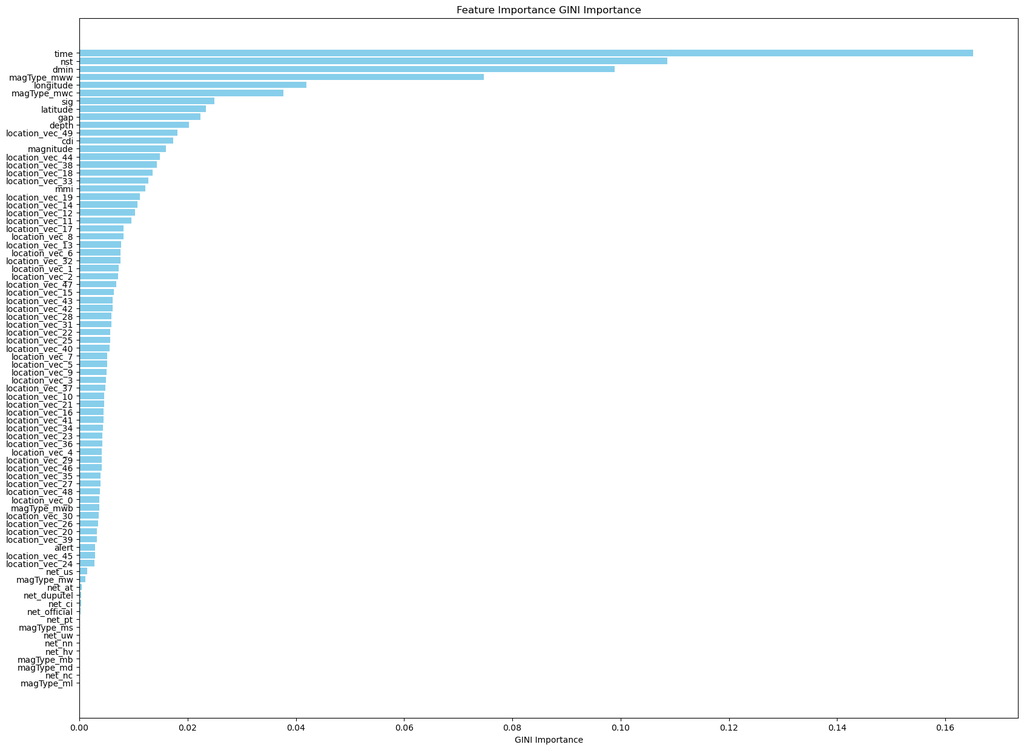

```python
plt.figure(figsize=(20, 15))
plt.barh(feature_imp_df['Features'], feature_imp_df['GINI Importance'], color='skyblue')
plt.xlabel('GINI Importance')
plt.title('Feature Importance GINI Importance')
plt.gca().invert_yaxis()
plt.show()
```

```python
# Drop time column first (model was learning temporal patterns instead of earthquake patterns)
X_train = X_train.drop(columns=['time'])
X_test = X_test.drop(columns=['time'])
```

```python
X_train_importance = calculate_gini_importance(X_train, y_train)
```

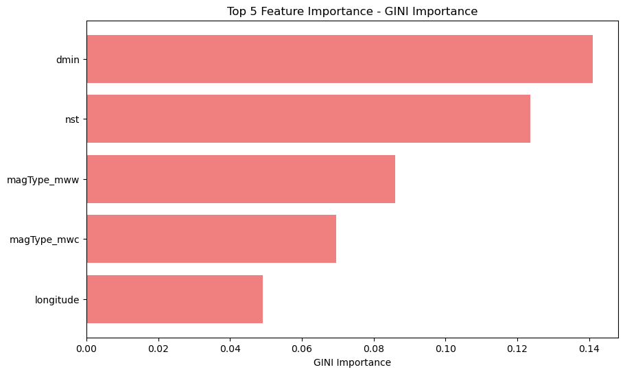

```python
top_5_features = X_train_importance.head(5)
plt.figure(figsize=(10, 6))
plt.barh(top_5_features['Features'], top_5_features['GINI Importance'], color='lightcoral')
plt.xlabel('GINI Importance')
plt.title('Top 5 Feature Importance - GINI Importance')
plt.gca().invert_yaxis()
plt.show()
```

```python
net_columns = []
for col in X_train.columns:
    if col.startswith('net_'):
        net_columns.append(col)
net_importance = X_train_importance[X_train_importance['Features'].isin(net_columns)]
print(net_importance)
```

```
        Features  GINI Importance
19        net_us         0.001448
11        net_at         0.000455
17  net_official         0.000450
13   net_duputel         0.000300
12        net_ci         0.000058
14        net_hv         0.000033
18        net_pt         0.000000
16        net_nn         0.000000
15        net_nc         0.000000
20        net_uw         0.000000
```

```python
X_train = X_train.drop(columns=net_columns)
X_test = X_test.drop(columns=net_columns)
```

```
Total Gini Importance of location vector features: 0.34831387169052364
Gini Importance of dmin feature: 0.14105507425359742
```

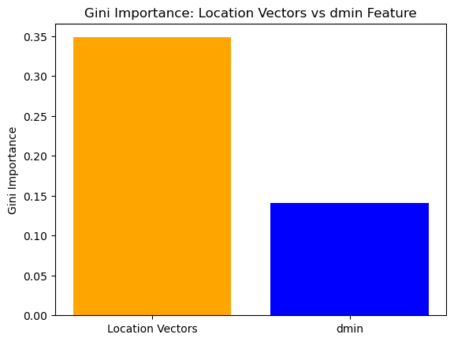

```python
#Code was losely based on template from (ChatGPT, 2025)
location_vector_columns = [col for col in X_train.columns if col.startswith('location_vec_')]
location_vector_importance = X_train_importance[X_train_importance['Features'].isin(location_vector_columns)]
total_location_vector_importance = location_vector_importance['GINI Importance'].sum()
print(f'Total Gini Importance of location vector features: {total_location_vector_importance}')
nst_importance = X_train_importance[X_train_importance['Features'] == 'dmin']['GINI Importance'].values[0]
print(f'Gini Importance of dmin feature: {nst_importance}')
plt.bar(['Location Vectors', 'dmin'], [total_location_vector_importance, nst_importance], color=['orange', 'blue'])
plt.title('Gini Importance: Location Vectors vs dmin Feature')
plt.ylabel('Gini Importance')
plt.show()
```

```python
magtype_drop_columns = ['magType_mb', 'magType_ms', 'magType_ml', 'magType_md', 'magType_mw', 'magType_mwb'] #dropping low importance features
X_train = X_train.drop(columns=magtype_drop_columns)
X_test = X_test.drop(columns=magtype_drop_columns)
```

#### Feature engineering

```python
X_train['general_significance'] = X_train[['sig', 'magnitude', 'cdi', 'mmi']].mean(axis=1)
X_test['general_significance'] = X_test[['sig', 'magnitude', 'cdi', 'mmi']].mean(axis=1)
```

```python
X_train['general_position'] = X_train[['latitude', 'longitude', 'depth']].mean(axis=1)
X_test['general_position'] = X_test[['latitude', 'longitude', 'depth']].mean(axis=1)
```

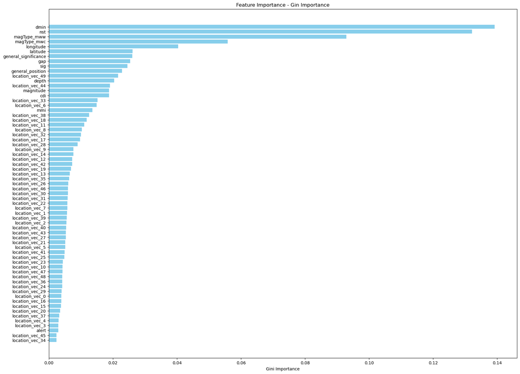

```python
feature_imp_df = calculate_gini_importance(X_train, y_train)
plt.figure(figsize=(20, 15))
plt.barh(feature_imp_df['Features'], feature_imp_df['GINI Importance'], color='skyblue')
plt.xlabel('Gini Importance')
plt.title('Feature Importance - Gin Importance')
plt.gca().invert_yaxis()
plt.show()
```

Figure 14: GINI Feature Importance Ranking

```python
from sklearn.inspection import permutation_importance
clf = RandomForestClassifier(n_estimators=100, random_state=42)
clf.fit(X_train, y_train)
result = permutation_importance(clf, X_test, y_test, n_repeats=10, random_state=0, n_jobs=-1)
perm_imp_df = pd.DataFrame({'Feature': X_train.columns, 'Permutation Importance': result.importances_mean}).sort_values('Permutation Importance', ascending=False)
```

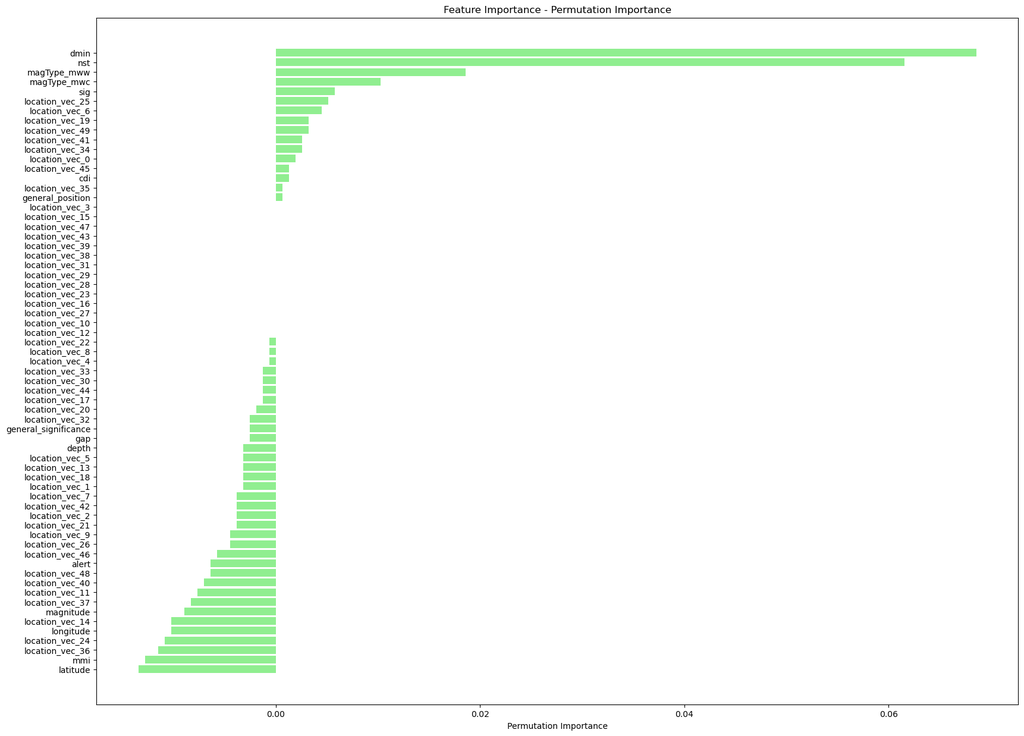

```python
plt.figure(figsize=(20, 15))
plt.barh(perm_imp_df['Feature'], perm_imp_df['Permutation Importance'], color='lightgreen')
plt.xlabel('Permutation Importance')
plt.title('Feature Importance - Permutation Importance')
plt.gca().invert_yaxis()
plt.show()
```

Figure 15: Premier interaction feature importance ranking

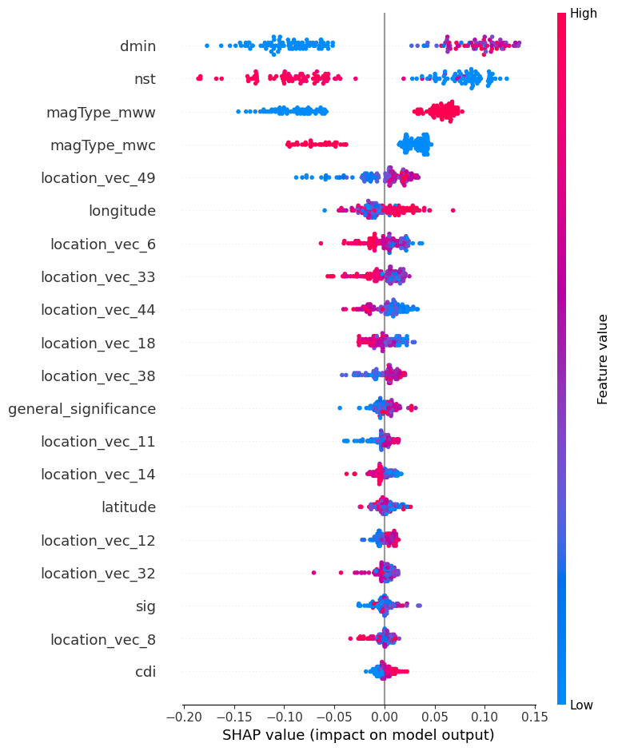

```python
import shap
explainer = shap.TreeExplainer(clf)
shap_values = explainer.shap_values(X_test)
shap_values_class1 = shap_values[:, :, 1]
shap.summary_plot(shap_values_class1, X_test, plot_type='dot')
```

Figure 16: SHAP Summary Plot Showing Feature Importance

#### Feature Importance Ranking (SHAP and GINI combined) along with Domain Relevance

Domain relevance dermined by consulting seismology literature on earthquake and tsunami relationships (Lomax, Michelini and Piatanesi, 2011; Wald et al., 2011; United States Geological Survey, 1989) and the table provided by (Chauhan, 2024).

Importance rankings considered both SHAP (figure 16) and GINI (figure 14) feature importance, and (figure 15) premutation importance when dermining overall feature importance.

| **Rank** | **Feature Name** | **Domain Relevance** |
| --- | --- | --- |
| 1 | Location Vectors (merged)* | Encodes geographic patterns and seismic hotspots. |
| 2 | dmin | Distance to nearest station, affects location accuracy. |
| 3 | nst | Number of reporting stations, higher counts improve reliability. |
| 4 | magType_mww | Moment magnitude method, affects magnitude measurement. |
| 5 | magType_mwc | Alternatve magnitude method, aids in cross-checking readings. |
| 6 | longitude | Longitude coordinate, key for mapping and regional analysis. |
| 7 | latitude | Latitude coordinate, identifes location. |
| 8 | sig | Significance of a seismic event determined by muliple sources |
| 9 | cdi | Reported intensity, indicates how strongly the quake was felt. |
| 10 | general_significance | Mean of `sig`, `magnitude`, `cdi`, and `mmi`; |

*Merging location vector importance isn’t a perfect metric, but the generally sensible ranking supports its inclusion.

### An imbalnced dataset

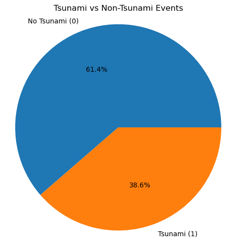

```python
plt.figure(figsize=(6,6))
plt.pie(y.value_counts(), labels=['No Tsunami (0)', 'Tsunami (1)'], autopct='%1.1f%%') #autopact from Matplotlib documentation (Matplotlib, no date)
plt.title('Tsunami vs Non-Tsunami Events')
plt.axis('equal')
plt.show()
```

#### Dataset imbalance handling techniques discussion

Examining the chart I can see that our dataset is imbalanced, with a significantly higher proportion of non-tsunami events (0) compared to tsunami events (1). In order to address this class imbalance during model training I will use class weights depending on model compatibility (Google LLC, 2025). SMOTE is another technique for handling imbalanced datasets by generating synthetic samples for the minority class. However, given our small dataset size and high dimensionality due to embedding features, using SMOTE could lead to overfitting and may not be effective as explored by Blagus & Lusa.

(Blagus & Lusa,2013)

## Ethics and Privacy Considerations

While our dataset contains no personally identifiable information about individuals, there are still important ethical considerations to keep in mind when working with this data. Especially around deployment, any model used for tsunami prediction must be rigorously tested to avoid false positives or negatives predictions that could lead to unnecessary concern or danger for populations at risk, this will make precision and recall key metrics to focus on during model evaluation. Furthermore, a consideration must be made for accessibility for poorer and remote communities who may not have access to expensive high compute resources.

## Model Selection Rationale

As mentioned in the dataset insights and feature types section, our dataset and `tsunami` target variable are well suited for binary classification models (figure 4). Given the small dataset size and class imbalance, I will focus on models that can handle these challenges effectively and acknowling our small dataset size, I must choose models that are less prone to overfitting.

### Model 1: Logistic Regression with Class Weights

Logistic regression is a simple but effective method for binary classification (Lee, 2025). It models the probability of a tsunami event using a sigmoid function and allows class weighting to address the dataset’s imbalance (Google LLC, 2025). It also performs well when the number of features compares disproportionately to the number of samples, as in our vectorised dataset, though this typically requires careful regularisation and hyperparameter tuning (Wainwright, Ravikumar & Lafferty, 2006).

Logistic regression is considered to be a less resource intensive algorithm compared to more complex models like neural networks or ensemble methods. This makes it a suitable choice for deployment in low-resource settings, such as remote communities that may not have access to high compute resources as discussed in the ethics and privacy considerations section, (Ayer et al., 2010).

### Model 2: Gradient Boosting classifier

Gradient Boosting Classifier is an ensemble learning method that builds a strong classifier by combining multiple weak decision trees. It iteratively adds trees that correct the errors of previous trees, leading to improved predictive performance (Friedman, 1999). Gradient boosting is less prone to overfitting compared to single decision trees, making it suitable for our small dataset (Natekin & Knoll, 2013). Gradient decision trees can be highly sesnsitive to class imbalance (Luo, 2024), and our sklearn implementation does not allow for class weighting. This is a limiation that could impact model performance on our imbalanced dataset.

Gradient boosting is more computationally intensive than logistic regression, however in comparison to deep learning models, it is still relatively efficient and can be optimized for deployment in low-resource settings with appropriate hyperparameter tuning (Peter et al., 2017).

## Research questions

#### Will a gradient boosting classifier outperform logistic regression in predicting tsunami occurrence following earthquakes based on seismic event characteristics?

This question aims to compare the performance of two different types of model. This question is influenced by our overall goal of building an accurate tsunami prediction model. The answer to this question is of great importaance as selecting the right model architecture is crucial for achieving high predictive accuracy, something that is vital for effective disaster management and early warning systems intent on predicting tsunamis.

#### Which feature will be the most important predictor of tsunami occurrence following earthquakes?

Given the diversity of features in our dataset, this question aims to identify which specific feature has the highest predictive power for tsunami occurrence. Understanding feature importance can provide insights into the underlying factors that contribute to tsunami generation, which is valuable for both scientific understanding and practical applications in tsunami risk assessment.

## Model Training

```python
from sklearn.model_selection import StratifiedKFold, cross_val_score
k_folds = StratifiedKFold(n_splits=10, shuffle=True, random_state=42)
X_recombined, y_recombined = pd.concat([X_train, X_test], axis=0), pd.concat([y_train, y_test], axis=0)
```

```python
def overfit_underfit_analysis(train_score, cross_val_score):
    print(f'Training Score: {train_score}')
    print(f'Cross Validation Score: {cross_val_score}')
    if train_score - cross_val_score > 0.01:
        print('The model is overfitting.')
        print(f'Difference: {train_score - cross_val_score}')
    elif cross_val_score - train_score > 0.01:
        print('The model is underfitting.')
        print(f'Difference: {cross_val_score - train_score}')
    else:
        print('The model has a good fit.')
```

The above method of detecting overfitting and underfitting is supported by (Aburass, 2023).

### Model 1: Logistic Regression

```python
from sklearn.linear_model import LogisticRegression
from sklearn.metrics import accuracy_score
logclf = LogisticRegression(class_weight='balanced')
logclf.fit(X_train, y_train)
```

```
LogisticRegression(class_weight='balanced')
```

```python
logclf_train_score = accuracy_score(y_train, logclf.predict(X_train))
print(f'Accuracy Score on Training Set: {logclf_train_score}')
```

```
Accuracy Score on Training Set: 0.8828250401284109
```

```python
logclf_test_score = accuracy_score(y_test, logclf.predict(X_test))
print(f'Accuracy Score on Test Set: {logclf_test_score}')
```

```
Accuracy Score on Test Set: 0.8653846153846154
```

```python
predictions_clf = logclf.predict(X_test)
logclf_cross_val_scores = cross_val_score(logclf, X_recombined, y_recombined, cv=k_folds)
print(f'Logistic Regression Cross-Validation Scores: {logclf_cross_val_scores}')
print(f'Logistic Regression Mean CV Score: {logclf_cross_val_scores.mean()}')
```

```
Logistic Regression Cross-Validation Scores: [0.8974359  0.88461538 0.79487179 0.85897436 0.88461538 0.8974359
 0.92307692 0.82051282 0.78205128 0.88311688]
Logistic Regression Mean CV Score: 0.8626706626706626
```

```python
overfit_underfit_analysis(logclf_train_score, logclf_cross_val_scores.mean())
```

```
Training Score: 0.8828250401284109
Cross Validation Score: 0.8626706626706626
The model is overfitting.
Difference: 0.020154377457748285
```

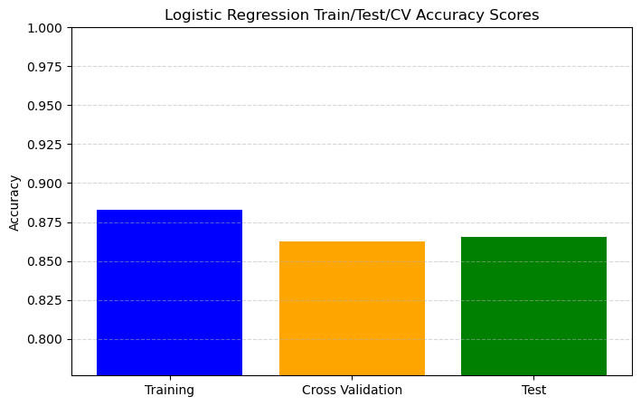

```python
import matplotlib.pyplot as plt

scores = [
    logclf_train_score,
    logclf_cross_val_scores.mean(),
    logclf_test_score
]

labels = ['Training', 'Cross Validation', 'Test']

plt.figure(figsize=(8,5))
plt.bar(labels, scores, color=['blue', 'orange', 'green'])
plt.ylim(0.9 * min(scores), 1)# (ChatGPT, 2025)
plt.ylabel("Accuracy")
plt.title('Logistic Regression Train/Test/CV Accuracy Scores')
plt.grid(axis='y', linestyle='--', alpha=0.5)
plt.show()
```

#### Hyperparameter Tuning for Logistic Regression

Our logistic regression model has achieved a good baseline performance, but there is still room for improvement through hyperparameter tuning, especially around regularization strength as the model appears to be overfitting slightly given the difference between training and cross-validation scores. I will preform a grid search on a selection of hyperparameters to identify the optimal combination that maximizes model performance while minimizing overfitting (figure 19).

| Parameter | Description | Effect on Overfitting problem |
| --- | --- | --- |
| C | Inverse of regularization strength. Smaller values mean stronger regularization, simpler model. Larger values mean weaker regularization. | Smaller C → reduces overfitting. |
| penalty | Type of regularization. 'l2' adds squared weight penalty to shrink weights and reduce overfitting. | 'l2' → controls overfitting. |
| class_weight | Adjusts importance of classes for imbalanced datasets. 'balanced' scales inversely to class frequency. | Balanced classes → reduces bias overfitting. |
| max_iter | Maximum number of iterations for solver convergence. Too low may prevent convergence; higher values allow full optimization. | Not directly related → does not meaningfully affect overfitting. |
| tol | Tolerance for stopping criteria. Smaller values give more precise convergence and longer training. Larger values stop earlier and train faster. | Not directly related → minor indirect impact at most. |
| solver | Algorithm for optimization. 'liblinear' is good for small datasets and supports L1 & L2; 'lbfgs' (default) is better for larger datasets. | Solver choice → affects stability, not overfitting. |

figure 19: Explanations of Logistic Regression Hyperparameters

#### Exploring C (regularization strength)

```python
hyperparameters = {
    'penalty':'l2', #regularization type
    'C':0.1, #regularization strength (inverse ratio - smaller values specify stronger regularization)
    'class_weight':'balanced' #address class imbalance (as before)
}

# Previous hyperparameter attempts:
#hyperparameters = {
#    'penalty':'l2',
#    'C':0.1,
#    'class_weight':'balanced'
#}

#hyperparameters = {
#    'penalty':'l2',
#    'C':0.05,
#    'class_weight':'balanced'
#}

#hyperparameters = {
#    'penalty':'l2',
#    'C':0.5,
#    'class_weight':'balanced'
#}

#hyperparameters = {
#    'penalty':'l1',
#    'solver':'saga',
#    'C':0.1,
#    'class_weight':'balanced'
#}
```

```python
logclf_tuned = LogisticRegression(**hyperparameters)
logclf_tuned.fit(X_train, y_train)
```

```
LogisticRegression(C=0.1, class_weight='balanced')
```

```python
logclf_tuned_train_score = accuracy_score(y_train, logclf_tuned.predict(X_train))
print(f'Accuracy Score on Training Set: {logclf_tuned_train_score}')
logclf_tuned_test_score = accuracy_score(y_test, logclf_tuned.predict(X_test))
print(f'Accuracy Score on Test Set: {logclf_tuned_test_score}')
```

```
Accuracy Score on Training Set: 0.8764044943820225
Accuracy Score on Test Set: 0.8974358974358975
```

```python
logclf_tuned_cross_val_scores = cross_val_score(logclf_tuned, X_recombined, y_recombined, cv=k_folds)
print(f'Logistic Regression Tuned Cross-Validation Scores: {logclf_tuned_cross_val_scores}')
print(f'Logistic Regression Tuned Mean CV Score: {logclf_tuned_cross_val_scores.mean()}')
```

```
Logistic Regression Tuned Cross-Validation Scores: [0.88461538 0.8974359  0.83333333 0.91025641 0.87179487 0.8974359
 0.92307692 0.79487179 0.80769231 0.87012987]
Logistic Regression Tuned Mean CV Score: 0.869064269064269
```

```python
overfit_underfit_analysis(logclf_tuned_train_score, logclf_tuned_cross_val_scores.mean())
```

```
Training Score: 0.8764044943820225
Cross Validation Score: 0.869064269064269
The model has a good fit.
```

```python
print(f'Previous Logistic Regression Mean CV Score: {logclf_cross_val_scores.mean()}')
print(f'Tuned Logistic Regression Mean CV Score: {logclf_tuned_cross_val_scores.mean()}')
print(f'Improvement in Mean CV Score after Tuning: {logclf_tuned_cross_val_scores.mean() - logclf_cross_val_scores.mean()}')
```

```
Previous Logistic Regression Mean CV Score: 0.8626706626706626
Tuned Logistic Regression Mean CV Score: 0.869064269064269
Improvement in Mean CV Score after Tuning: 0.006393606393606421
```

#### Further Hyperparameter Tuning for general performance improvement (max iterations and tolerance)

```python
hyperparameters = {
    'C':hyperparameters['C'],
    'class_weight':'balanced',
    'max_iter':100, #increase max iterations to ensure convergence
    'tol':1e-4 #tolerance for stopping criteria (how much improvement is required to continue training)
}
#previously attempted:
#hyperparameters = {
#    'C':0.01, #keep previous best C value
#    'class_weight':'balanced',
#    'max_iter':200,
#    'tol':1e-3
#}

#hyperparameters = {
#    'C':0.01, #keep previous best C value
#    'class_weight':'balanced',
#    'max_iter':300,
#    'tol':1e-5
#}

#hyperparameters = {
#    'C':0.01, #keep previous best C value
#    'class_weight':'balanced',
#    'max_iter':300,
#    'tol':1e-5
#}

#hyperparameters = {
#    'C':0.01, #keep previous best C value
#    'class_weight':'balanced',
#    'max_iter':500,
#    'tol':1e-4
#}   'solver':'liblinear' #Known to work well with small datasets
```

```python
logclf_tuned_v2 = LogisticRegression(**hyperparameters)
logclf_tuned_v2.fit(X_train, y_train)
```

```
LogisticRegression(C=0.1, class_weight='balanced')
```

```python
logclf_tuned_cross_val_scores_general_performance = cross_val_score(logclf_tuned_v2, X_recombined, y_recombined, cv=k_folds)
print(f'Logistic Regression Tuned Cross-Validation Scores: {logclf_tuned_cross_val_scores_general_performance}')
print(f'Logistic Regression Tuned Mean CV Score: {logclf_tuned_cross_val_scores_general_performance.mean()}')
```

```
Logistic Regression Tuned Cross-Validation Scores: [0.88461538 0.8974359  0.83333333 0.91025641 0.87179487 0.8974359
 0.92307692 0.79487179 0.80769231 0.87012987]
Logistic Regression Tuned Mean CV Score: 0.869064269064269
```

```python
overfit_underfit_analysis(logclf_tuned_train_score, logclf_tuned_cross_val_scores.mean())
```

```
Training Score: 0.8764044943820225
Cross Validation Score: 0.869064269064269
The model has a good fit.
```

```python
print(f'Previous Logistic Regression Tuned Mean CV Score: {logclf_tuned_cross_val_scores.mean()}')
print(f'New Tuned Logistic Regression Mean CV Score: {logclf_tuned_cross_val_scores_general_performance.mean()}')
print(f'Improvement in Mean CV Score after Further Tuning: {logclf_tuned_cross_val_scores_general_performance.mean() - logclf_tuned_cross_val_scores.mean()}')
```

```
Previous Logistic Regression Tuned Mean CV Score: 0.869064269064269
New Tuned Logistic Regression Mean CV Score: 0.869064269064269
Improvement in Mean CV Score after Further Tuning: 0.0
```

#### Class weight tuning

```python
hyperparameters = {
    'C':0.01, #keep previous best C value
    'penalty':'l2',
    'class_weight':None, #remove class weights
}

#previously attempted:

# hyperparameters = {
#     'C':0.01, #keep previous best C value
#     'penalty':'l2',
#     'class_weight': {0: 2.0, 1: 1.0}, #adjust class weights to give more importance to non-tsunami class
# }
```

```python
logclf_tuned_no_class_weights = LogisticRegression(**hyperparameters)
logclf_tuned_no_class_weights.fit(X_train, y_train)
```

```
LogisticRegression(C=0.01)
```

```python
logclf_tuned_no_class_weights_train_score = accuracy_score(y_train, logclf_tuned_no_class_weights.predict(X_train))
print(f'Accuracy Score on Training Set without Class Weights: {logclf_tuned_no_class_weights_train_score}')
logclf_tuned_no_class_weights_test_score = accuracy_score(y_test, logclf_tuned_no_class_weights.predict(X_test))
print(f'Accuracy Score on Test Set without Class Weights: {logclf_tuned_no_class_weights_test_score}')
```

```
Accuracy Score on Training Set without Class Weights: 0.8812199036918138
Accuracy Score on Test Set without Class Weights: 0.8974358974358975
```

```python
logclf_tuned_no_class_weights_cross_val_scores = cross_val_score(logclf_tuned_no_class_weights, X_recombined, y_recombined, cv=k_folds)
print(f'Logistic Regression Tuned without Class Weights Cross-Validation Scores: {logclf_tuned_no_class_weights_cross_val_scores}')
print(f'Logistic Regression Tuned without Class Weights Mean CV Score: {logclf_tuned_no_class_weights_cross_val_scores.mean()}')
```

```
Logistic Regression Tuned without Class Weights Cross-Validation Scores: [0.8974359  0.88461538 0.83333333 0.92307692 0.85897436 0.88461538
 0.92307692 0.83333333 0.82051282 0.87012987]
Logistic Regression Tuned without Class Weights Mean CV Score: 0.8729104229104229
```

```python
print(f'Previous Best Tuned Logistic Regression Mean CV Score: {logclf_tuned_cross_val_scores.mean()}')
print(f'Logistic Regression without Class Weights Mean CV Score: {logclf_tuned_no_class_weights_cross_val_scores.mean()}')
print(f'Change in Mean CV Score after Removing Class Weights: {logclf_tuned_no_class_weights_cross_val_scores.mean() - logclf_tuned_cross_val_scores.mean()}')
```

```
Previous Best Tuned Logistic Regression Mean CV Score: 0.869064269064269
Logistic Regression without Class Weights Mean CV Score: 0.8729104229104229
Change in Mean CV Score after Removing Class Weights: 0.0038461538461538325
```

#### Hyperparameter Optimization and Visualization

```python
hyperparameters = {
    'C':[0.005,0.01, 0.1, 0.3, 0.5,0.8],
    'penalty':['l2'], #keep l2 regularization
    'class_weight':['balanced'], #keep class weights to address class imbalance
    'max_iter':[50,100, 200, 300, 500], #vary max iterations
    'tol':[1e-1,1e-2,1e-3, 1e-4, 1e-5], #vary tolerance
    'solver':['liblinear', 'lbfgs'] #try different solvers, other solvers don't support l2 penalty
}

results = {}
for param, values in hyperparameters.items():
    scores = []
    for val in values:
        params = {param: None}
        params[param] = val
        model = LogisticRegression(**params)
        cv = cross_val_score(model, X_recombined, y_recombined, cv=k_folds)
        scores.append(cv.mean())
    results[param] = (values, scores)
```

[output not shown]

[output cut: 35 more lines]

[output not shown]

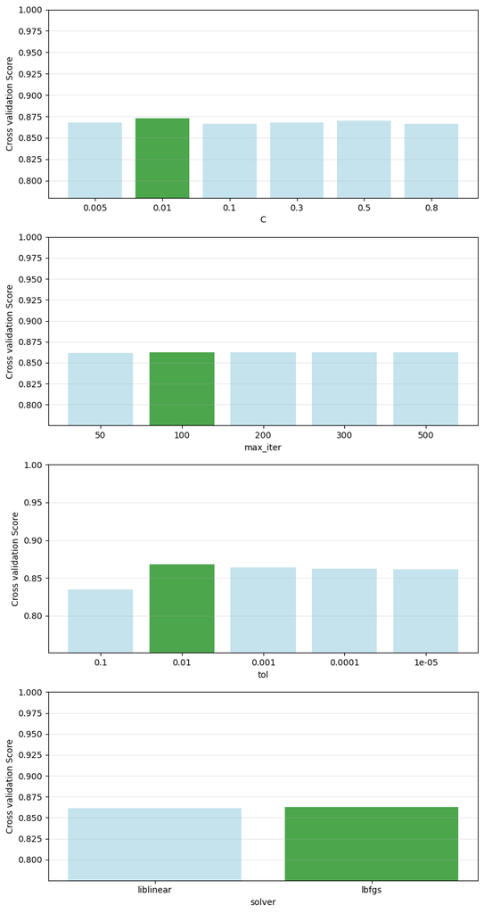

```python
fig, axes = plt.subplots(4, 1, figsize=(8, 15))

changable_hyperparemters = [param for param in hyperparameters.keys() if param != 'penalty' and param != 'class_weight']

for i, param in enumerate(changable_hyperparemters):

    scores = results[param][1]
    best_idx = scores.index(max(scores))
    colors = ['green' if j == best_idx else 'lightblue' for j in range(len(scores))] # (ChatGPT, 2025)
    axes[i].bar(range(len(results[param][0])), results[param][1], color=colors, alpha=0.7)
    axes[i].set_xlabel(param)
    axes[i].set_ylabel('Cross validation Score')
    axes[i].set_xticks(range(len(results[param][0])))
    axes[i].set_xticklabels(results[param][0])
    axes[i].set_ylim(0.9 * min(results[param][1]), 1)
    axes[i].grid(True, alpha=0.3, axis='y')

plt.tight_layout()
plt.show()
```